# Case Study 1

Elaine Ji

2019/7/27

# Discussion

This is a data set about toys for sale on Amazon, which covers nearly everything that customers can see on Amazon’s website. In the face of this real and chaotic data set, although there is have no obvious business problems to solve, we can get some inspirations about supplier selection from the data.

The variables in the data set can be divided into three major parts: **Product data, Seller data**, and **Buyer data**. These three make up the Amazon’s data ocean. By analyzing the relationships among the three types of data, we can peek into the connections between buyers and sellers on Amazon’s website through products.

In addition, I also try to explore the factors that may influence review rating, so as to predict the portrait of Amazon’s consumer group.

# Part 1: Data Cleaning and Wrangling

## Initial setup

```r
library(tidyverse)
library(reshape2)
library(dplyr)
library(tidyr)
library(stringr)
```

## Data Quality and Wrangling

**1. Issues**

After observing this dataset, I found the following issues:

- Some variables have characters that we don’t need  
  e.g. price, average_review_rating
- One column contains several variables  
  e.g. number_available_in_stock, amazon_category_and_sub_category, customer_questions_and_answers, customer_reviews, sellers
- One row contains several observations  
  e.g. customers_who_bought_this_item_also_bought, items_customers_buy_after_viewing_this_item, customer_questions_and_answers, customer_reviews, sellers
- Two columns have nearly the same informations  
  e.g. description, product_description

**2. Tidy the data**

```r
#Remove null columns
toys <- toys[,-(18:ncol(toys))]

#Remove needless characters and convert to numeric
toys$price <- as.numeric(substr(toys$price,2,10))
toys$average_review_rating <- as.numeric(substr(toys$average_review_rating,1,3))

#Separate variables into multiple columns
df <- toys %>%
  separate(amazon_category_and_sub_category,
           into = c("cate1","cate2","cate3","cate4","cate5") ,sep = ">")
df <- df %>%
  separate(number_available_in_stock,into = c("stock_number","stock_status") )

#Count numbers of element and save to new column
df$customer_also_bought_num <-
  str_count(df$customers_who_bought_this_item_also_bought,"http://")
df$customer_viewed_also_bought_num <-
  str_count(df$items_customers_buy_after_viewing_this_item,"http://")

#Separate observations into multiple rows and save into new datasets
a <- separate_rows(df,customers_who_bought_this_item_also_bought,
                   sep = "\\|",convert = TRUE)
a <- a[,c(1,14)]
b <- separate_rows(df,items_customers_buy_after_viewing_this_item,
                   sep = "\\|",convert = TRUE)
b <- b[,c(1,18)]

#Remove the repetitive variable
df <- df[,-16]

#Separate observations into multiple rows then separate variables into multiple columns. Save into new datasets
c<- separate_rows(df,customer_questions_and_answers,
                  sep = "\\|",convert = TRUE)
c <- c[,c(1,19)]
c <- separate(c,customer_questions_and_answers,
              into = c("question","answer"),sep = "//")

d <- separate_rows(df,customer_reviews,
                   sep = "\\|",convert = TRUE)
d <- d[,c(1,20)]
d <- separate(d,customer_reviews,
              into = c("review_title","review_rating","review_time",
                       "review_name","review_content"), sep = "//")
d$review_name <- substr(d$review_name,14,(nchar(d$review_name)-17))

e <- separate_rows(df,sellers,sep = '"Seller_name_')
w <- grep(pattern = 'seller"=>',e$sellers,ignore.case = FALSE)
e <- e[-w,c(1,21)]
e <- separate(e,sellers,into = c("seller_name","seller_price"),sep = "Seller_price_")
e <- separate(e,seller_name,into=c("1","2","seller_name","4"),sep = '\"')
e <- e[,c(1,4,6)]
e <- separate(e,seller_price,into=c("1","2","seller_price","4"),sep = '\"')
e <- e[,c(1,2,5)]
e$seller_price <- as.numeric(substr(e$seller_price,2,10))

#Merge observations into one row and save it to the summary dataset
customer_questions<- c %>% group_by(uniq_id)%>%
  summarize(question=paste(question,collapse = " | "))
customer_answers<- c %>% group_by(uniq_id)%>%
  summarize(answer=paste(answer,collapse = " | "))
df2<- merge(df,customer_questions)
df2 <- merge(df2,customer_answers)
df2 <- df2[-c(1,2),]

review_titles <-d %>% group_by(uniq_id)%>%
  summarize(review_title=paste(review_title,collapse = " | "))
review_contents <- d %>% group_by(uniq_id)%>%
  summarize(review_content=paste(review_content,collapse = " | "))
df2<- merge(df2,review_titles)
df2 <- merge(df2,review_contents)

sellers_name <- e %>% group_by(uniq_id)%>%
  summarize(seller_name=paste(seller_name,collapse = " | "))
df2<- merge(df2,sellers_name)
df2$stock_number <- as.numeric(paste(df2$stock_number))
df2 <- df2[,c(1:3,10:14,4:9,16,17,22:28,18,15)]
```

## Missing values

In the real world data, missing values are inevitable. It would be too extreme to delete all the missing values. However, it’s better to use `na.rm=TRUE` to omit missing values before analysis.

```r
length(which(is.na(df2$manufacturer)))
```

```
## [1] 6
```

```r
length(which(is.na(df2$cate1)))
```

```
## [1] 690
```

```r
length(which(is.na(df2$price)))
```

```
## [1] 1454
```

## New Metadata

After data manipulation, I created one summary dataset and five small tables. I think it’s the best way to not only keep the summary dataset clean and tidy (rather than redundant), but also do not lose any useful observation.

**1. TABLE 1: *df2***

`names(df2)`

[1] “uniq_id”  
[2] “product_name”  
[3] “manufacturer”: The item manufacturer, as reported on Amazon.  
[4] “cate1”: Categorization for the item  
[5] “cate2”: The first sub category for the item  
[6] “cate3”: The second sub category for the item  
[7] “cate4”: The third sub category for the item  
[8] “cate5”: The forth sub category for the item  
[9] “price”  
[10] “stock_number”: The number available in stock  
[11] “stock_status”: The status (new or used) available in stock  
[12] “number_of_reviews”: Number of customer reviews  
[13] “number_of_answered_questions”: Number of answered questions  
[14] “average_review_rating”  
[15] “product_information”  
[16] “product_description”  
[17] “customer_also_bought_num”: Number of items that similar users bought  
[18] “customer_viewed_also_bought_num”:Number of items similar viewers bought  
[19] “question”: The summary of all questions that people asked  
[20] “answer”: The summary of all answers of the questions  
[21] “review_title”: The summary of all headlines of customer reviews  
[22] “review_content”: The summary of all contents of customer reviews  
[23] “seller_name”: The summary of all sellers’ name  
[24] “items_customers_buy_after_viewing_this_item”: Items similar viewers buy  
[25] “customers_who_bought_this_item_also_bought”: Items similar users buy

**2. TABLE 2: *a***

`names(a)`

[1] “uniq_id”  
[2] “customers_who_bought_this_item_also_bought”

**3. TABLE 3: *b***

`names(b)`

[1] “uniq_id”  
[2] “items_customers_buy_after_viewing_this_item”

**4. TABLE 3: *c***

`names(c)`

[1] “uniq_id”  
[2] “question” [3] “answer”

**5. TABLE 3: *d***

`names(d)`

[1] “uniq_id”  
[2] “review_title”  
[3] “review_rating”  
[4] “review_time”  
[5] “review_name”  
[6] “review_content”

**6. TABLE 3: *e***

`names(e)`

[1] “uniq_id”  
[2] “seller_name”  
[3] “seller_price”

# Part 2: Data Analysis

## Product

Product is Amazon’s blood. Amazon has many kinds of toys, which are presented as “category” in this data.

*What kinds of products have the most brands, the most products, the highest prices, and the most inventory?*

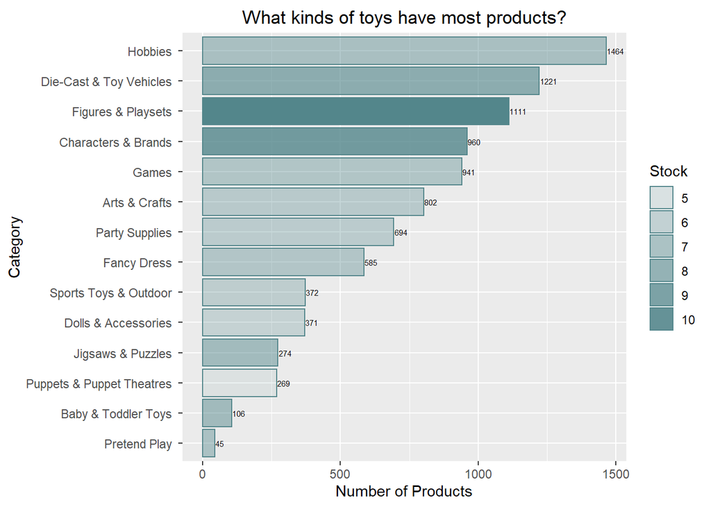

```r
#Data Manipulation#
cate_summary <-
  df2 %>%
    group_by(cate1) %>%
    summarize(Count = n(),Rate=mean(average_review_rating,na.rm = TRUE),Reviews=mean(number_of_reviews,na.rm = TRUE),Answers=mean(number_of_answered_questions,na.rm = TRUE),Stock=mean(stock_number,na.rm = TRUE),Price=mean(price,na.rm = TRUE),Manufacturer=length(levels(factor(manufacturer))))

#Visualization#
#What kinds of toys have most products?
cate_count<- na.exclude(subset(cate_summary,Count>20))
ggplot(data = cate_count, mapping = aes(x = reorder(cate1,Count),y=Count)) +
  geom_col(aes(alpha=Stock),color = "cadetblue4",fill="cadetblue4") +
  labs(x="Category",y="Number of Products",title = "What kinds of toys have most products?") +
  coord_flip()+
  geom_text(label=round(cate_count$Count,2),check_overlap = TRUE,size=2,color="black",hjust=-0.05)+
  theme(plot.title = element_text(hjust =0.5, vjust=0.5))
```

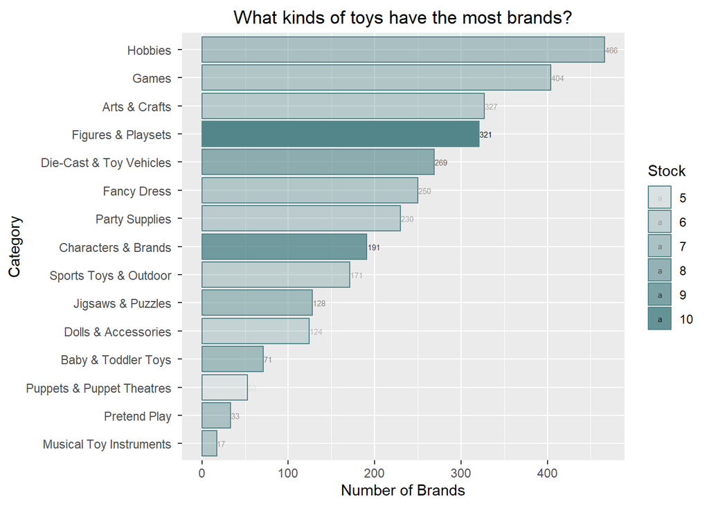

```r
#What kinds of toys have the most brands?
cate_brand<- na.exclude(subset(cate_summary,Manufacturer>15))
ggplot(data = cate_brand, mapping = aes(x = reorder(cate1,Manufacturer),y=Manufacturer,alpha=Stock)) +
  geom_col(fill="cadetblue4",color = "cadetblue4") +
  labs(x="Category",y="Number of Brands",title = "What kinds of toys have the most brands?") +
  coord_flip()+
  geom_text(label=round(cate_brand$Manufacturer,2),check_overlap = TRUE,size=2,color="black",hjust=-0.05)+
  theme(plot.title = element_text(hjust =0.5, vjust=0.5))
```

## Seller

If product is Amazon’s blood, seller would be Amazon’s blood vessel. There are thousands of toys’ brands in Amazon, which are presented as “manufacturer” in this data.

*What brands have the widest product lines, the largest number of products, the highest prices, and the largest inventory?*

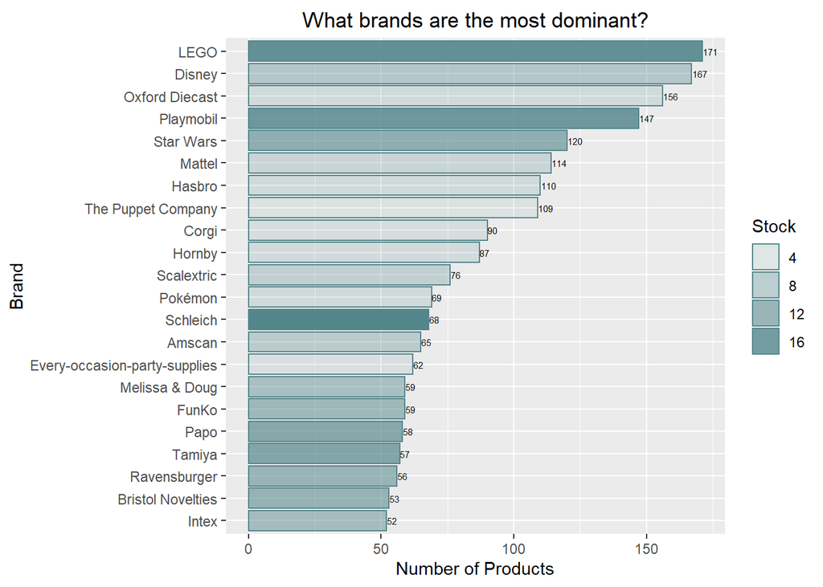

```r
#Data Manipulation#
brand_summary <-
  df2 %>%
    group_by(manufacturer) %>%
    summarize(Count = n(),Rate=mean(average_review_rating,na.rm = TRUE),Reviews=mean(number_of_reviews,na.rm = TRUE),Answers=mean(number_of_answered_questions,na.rm = TRUE),Stock=mean(stock_number,na.rm = TRUE),Price=mean(price,na.rm = TRUE),Category=length(levels(factor(cate1))))
brand_summary$Review_level <- brand_summary$Reviews*brand_summary$Rate

#Visualiztion#
#What brands are the most dominant?
brand_count<- na.exclude(subset(brand_summary,Count>50))
ggplot(data = brand_count, mapping = aes(x = reorder(manufacturer,Count),y=Count)) +
  geom_col(aes(alpha=Stock),color = "cadetblue4", fill="cadetblue4") +
  labs(x="Brand",y="Number of Products",title = "What brands are the most dominant?") +
  coord_flip()+
  geom_text(label=round(brand_count$Count,2),check_overlap = TRUE,size=2,color="black",hjust=-0.05)+
  theme(plot.title = element_text(hjust =0.5, vjust=0.5))
```

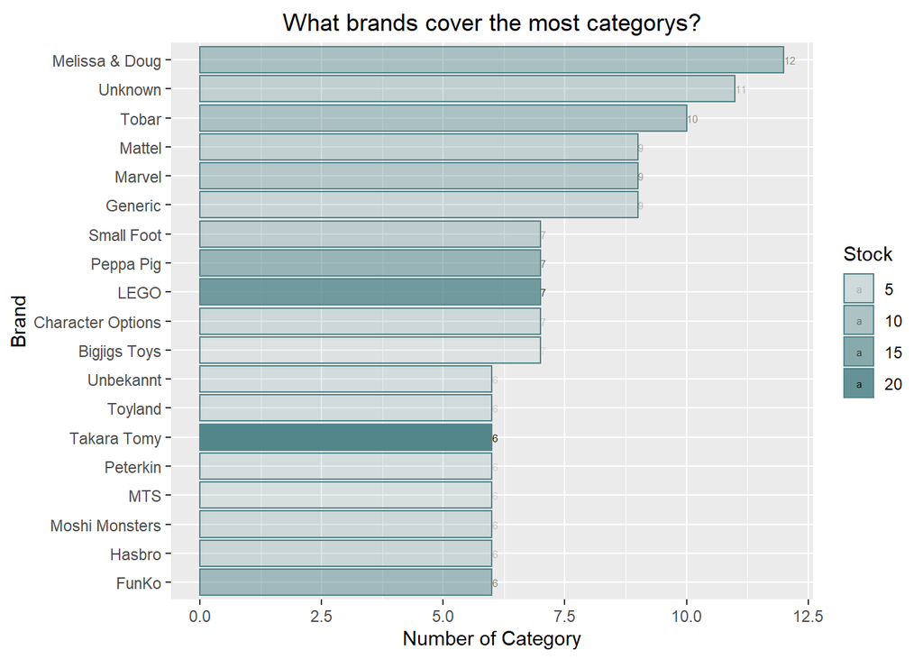

```r
#What brands cover the most categorys?
brand_cate<- na.exclude(subset(brand_summary,Category>5))
ggplot(data = brand_cate, mapping = aes(x = reorder(manufacturer,Category),y=Category,alpha=Stock)) +
  geom_col(fill="cadetblue4",color = "cadetblue4") +
  labs(x="Brand",y="Number of Category",title = "What brands cover the most categorys?") +
  coord_flip()+
  geom_text(label=round(brand_cate$Category,2),check_overlap = TRUE,size=2,color="black",hjust=-0.05)+
  theme(plot.title = element_text(hjust =0.5, vjust=0.5))
```

## Buyer

Every interaction of customers on amazon’s website will leave a footprint, forming valuable data resources of amazon. There are several ways for customers to leave a footprint, including writing reviews, rating, asking questions and answering.

*What kinds of products and brands get the best reviews, the most reviews and answered questions?*

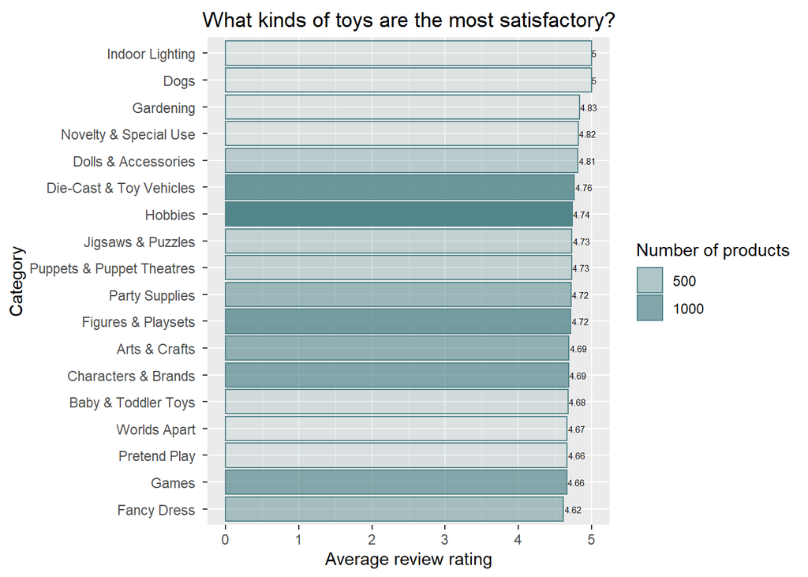

```r
#What kinds of toys are the most satisfactory?
cate_rate <- na.exclude(subset(cate_summary,Rate>4.6))
ggplot(data = cate_rate,mapping = aes(x = reorder(cate1, Rate),y = Rate)) +
  geom_col(aes(alpha = cate_rate$Count),color = "cadetblue4", fill = "cadetblue4") +
  labs( x = "Category",y = "Average review rating",alpha = "Number of products",
  title = "What kinds of toys are the most satisfactory?") +
  coord_flip()+
  geom_text(label=round(cate_rate$Rate,2),check_overlap = TRUE,size=2,color="black",hjust=-0.05)+
  theme(plot.title = element_text(hjust =0.5, vjust=0.5))
```

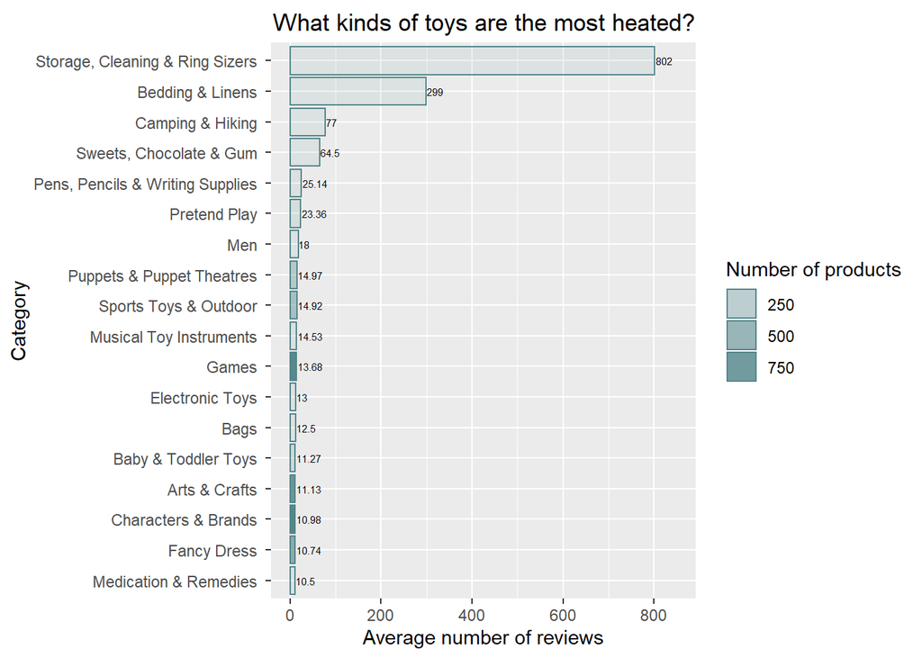

```r
#What kinds of toys are the most heated?
cate_review <- na.exclude(subset(cate_summary,Reviews>10))
ggplot(data = cate_review ,mapping = aes(x = reorder(cate1, Reviews),y = Reviews)) +
  geom_col(aes(alpha = Count),
  color = "cadetblue4", fill = "cadetblue4" ) +
  labs( x = "Category",y = "Average number of reviews",alpha = "Number of products",
  title = "What kinds of toys are the most heated?") +
  coord_flip()+
  geom_text(label=round(cate_review$Reviews,2),check_overlap = TRUE,size=2,color="black",hjust=-0.05)+
  theme(plot.title = element_text(hjust =0.5, vjust=0.5))+
  ylim(0,850)
```

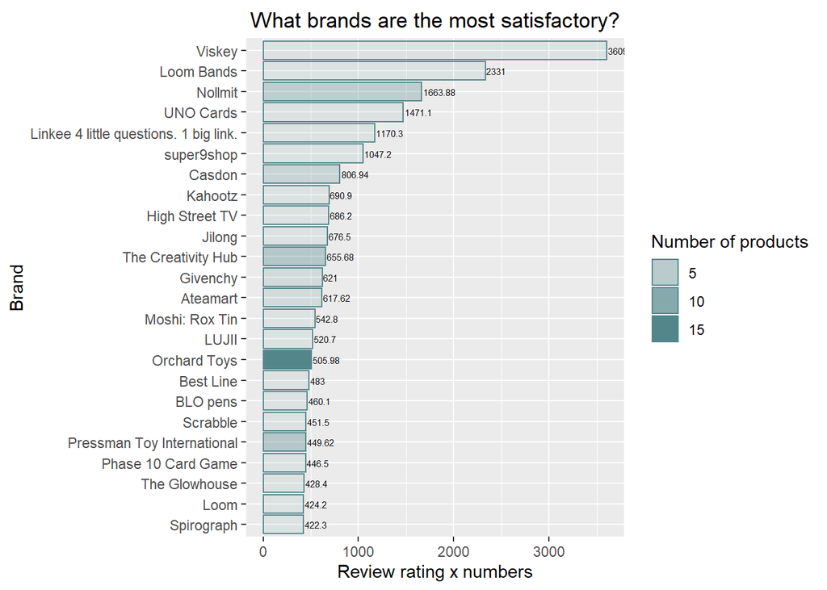

```r
#What brands are the most satisfactory?
brand_rate <- na.exclude(subset(brand_summary,Review_level>400))
ggplot(data = brand_rate,mapping = aes(x = reorder(manufacturer, Review_level),y = Review_level)) +
  geom_col(aes(alpha = brand_rate$Count),color = "cadetblue4", fill = "cadetblue4") +
  labs( x = "Brand",y = "Review rating x numbers",alpha = "Number of products",
  title = "What brands are the most satisfactory?") +
  theme(plot.title = element_text(hjust =0.5, vjust=0.5))+
  coord_flip()+
  geom_text(label=round(brand_rate$Review_level,2),check_overlap = TRUE,size=2,color="black",hjust=-0.05)
```

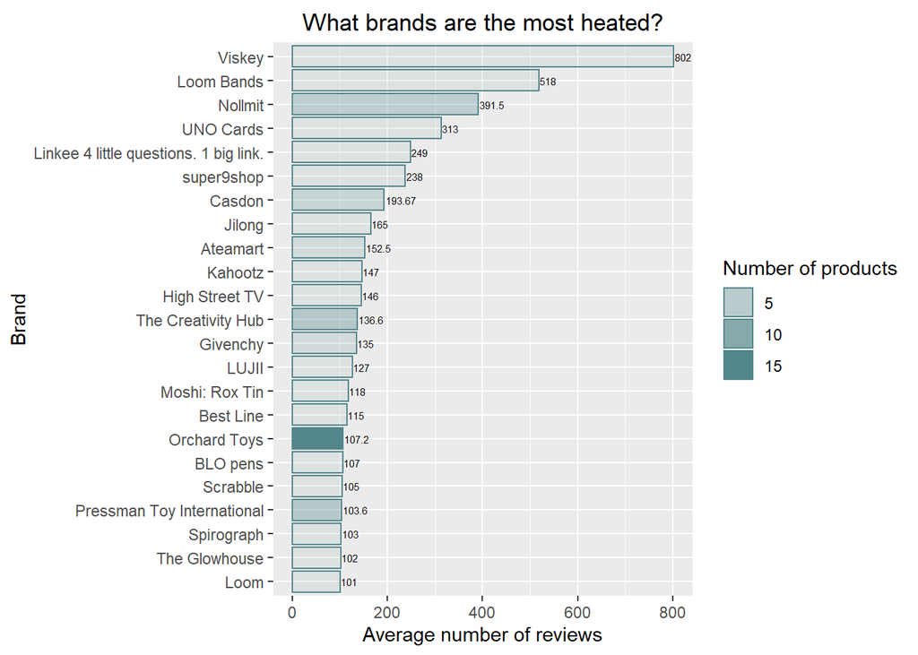

```r
#What brands are the most heated?
brand_review <- na.exclude(subset(brand_summary,Reviews>100))
ggplot(data = brand_review ,mapping = aes(x = reorder(manufacturer, Reviews),y = Reviews)) +
  geom_col(aes(alpha = Count),
  color = "cadetblue4", fill = "cadetblue4" ) +
  labs( x = "Brand",y = "Average number of reviews",alpha = "Number of products",
  title = "What brands are the most heated?") +
  coord_flip()+
  geom_text(label=round(brand_review$Reviews,2),check_overlap = TRUE,size=2,color="black",hjust=-0.05)+
  theme(plot.title = element_text(hjust =0.5, vjust=0.5))
```

# Part 3: What’s More?

## Customer Characteristic

I try to explore the factors that may influence review rating, so as to predict the portrait of Amazon’s consumer group.

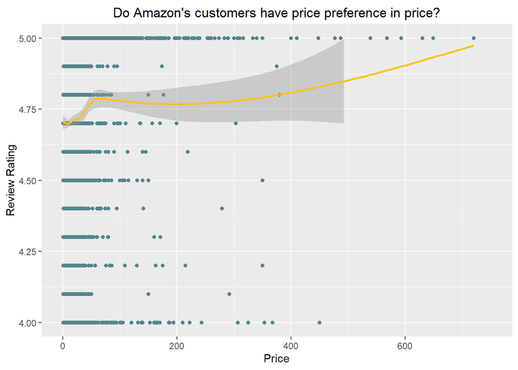

```r
#What are the factors that may influence review rating?
#price x rating
ggplot(data = df2,mapping = aes(x = price,y = average_review_rating)) +
  geom_point(color = "cadetblue4")+
  geom_smooth(color="goldenrod1") +
  labs( x = "Price",y = "Review Rating",
  title = "Do Amazon's customers have price preference in price?") +
  theme(plot.title = element_text(hjust =0.5, vjust=0.5))+
  ylim(4,5)+
  xlim(0,750)
```

## Additional Data?

There are some key variables that are not offered in this dataset.

- We have no “number of sales”. So it’s hard to tell the popularity.
- we have no “number of questions”. We just have “number of answered questions”. So, we cannot calculate the ratio of the question answering. This ratio can show the attention degree of a particular product.
- we have no “cost of product”. We only have the price. So we can not figure out the profit.

Maybe our next step is to collect the missing data above, in order to fulfill the analysis.

## Textual and Sentiment Analysis?

There are many character variables in the dataset that I haven’t analysis at this stage. Variables like “customer reviews”, “customer questions” and “customer answers” have a lot of hidden value, waiting to be discovered by more powerful analytical techniques. I think textual analysis and sentiment analysis are our future tasks.

# Part 4: Appendix

More graphs are made for questions including:  
What kinds / brands of toys are the most available in stock?  
What kinds / brands of toys are the most expensive?  
What kinds / brands of toys have the most answers?  
Will number of answers / available in stock influence review rating?

You can see them in the rmd file.